# Modele parametyczne - projekt

Piotr Zebrowski & Michał Wierucki

2/7/2021

Zbiór danych zawiera klientów kart kredytowych oraz ich cechy:

#### Zbiór danych i przykładowe obserwacje

| Attrition_Flag | Customer_Age | Gender | Dependent_count | Education_Level | Marital_Status | Income_Category | Card_Category | Months_on_book | Total_Relationship_Count | Months_Inactive_12_mon | Contacts_Count_12_mon | Credit_Limit | Total_Revolving_Bal | Avg_Open_To_Buy | Total_Amt_Chng_Q4_Q1 | Total_Trans_Amt | Total_Trans_Ct | Total_Ct_Chng_Q4_Q1 | Avg_Utilization_Ratio |
| --- | --- | --- | --- | --- | --- | --- | --- | --- | --- | --- | --- | --- | --- | --- | --- | --- | --- | --- | --- |
| Existing Customer | 45 | M | 3 | High School | Married | $60K - $80K | Blue | 39 | 5 | 1 | 3 | 12691 | 777 | 11914 | 1.335 | 1144 | 42 | 1.625 | 0.061 |
| Existing Customer | 49 | F | 5 | Graduate | Single | Less than $40K | Blue | 44 | 6 | 1 | 2 | 8256 | 864 | 7392 | 1.541 | 1291 | 33 | 3.714 | 0.105 |
| Existing Customer | 51 | M | 3 | Graduate | Married | $80K - $120K | Blue | 36 | 4 | 1 | 0 | 3418 | 0 | 3418 | 2.594 | 1887 | 20 | 2.333 | 0.000 |
| Existing Customer | 40 | F | 4 | High School | Unknown | Less than $40K | Blue | 34 | 3 | 4 | 1 | 3313 | 2517 | 796 | 1.405 | 1171 | 20 | 2.333 | 0.760 |
| Existing Customer | 40 | M | 3 | Uneducated | Married | $60K - $80K | Blue | 21 | 5 | 1 | 0 | 4716 | 0 | 4716 | 2.175 | 816 | 28 | 2.500 | 0.000 |
| Existing Customer | 44 | M | 2 | Graduate | Married | $40K - $60K | Blue | 36 | 3 | 1 | 2 | 4010 | 1247 | 2763 | 1.376 | 1088 | 24 | 0.846 | 0.311 |

#### Problem badawczy

W raporcie zostanie podjęta próba klasyfikacji klientów (zrezygnowanie lub z nie z usługi karty kredytowej) na podstawie wszystkich cech każdego osobnika w zbiorze danych.

#### Drzewo klasyfikacji

[figure not shown]

#### Podział zbioru na uczący i testowy

```r
testowe.nr <- sample(x = nrow(churners), size = nrow(churners)/4, replace = F)
churners.uczacy <- churners[-testowe.nr, ]
churners.testowy <- churners[testowe.nr, ]
```

*Funkcja losująca odpowiednie numery obserwacji do zbioru uczącego. Za pomocą funkcji losującej bez zwracania 3/4 zbioru przypisujemy do obiektu uczącego, a 1/4 do zbioru testowego.*

#### Ustalanie parametrów modelu

```r
drzewo.churners1 <- rpart(Attrition_Flag ~ .,
                         data = churners.uczacy,
                         control = rpart.control(cp = 0))
```

*Początkowo drzewo zostało wytworzone z zargumentem cp = 0, następnie poprawność argumentu została zweryfikowana za pomocą funkcji prezentującej wykres cp w naszym modelu drzewa.*

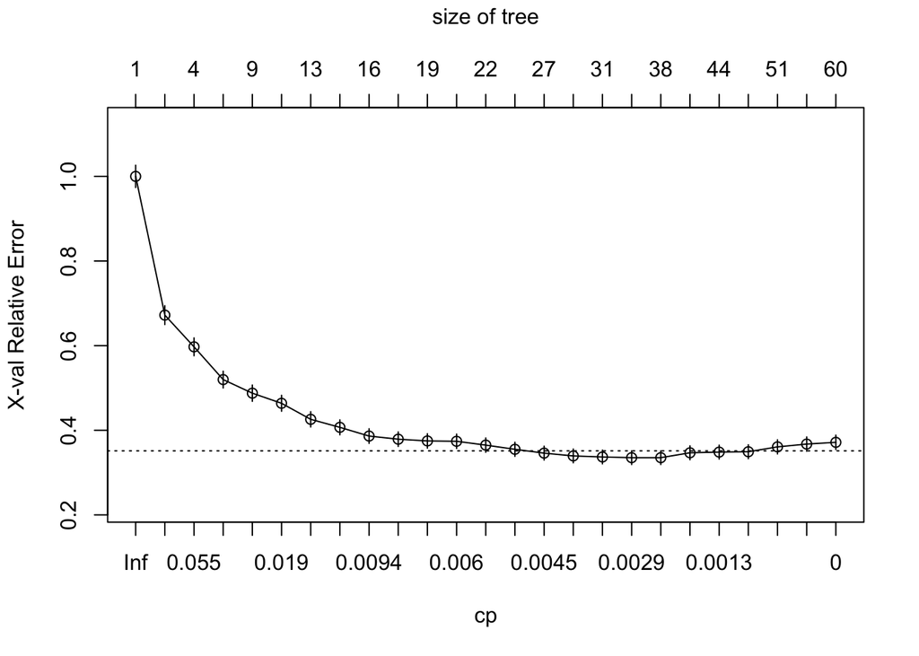

*Wykres informuje nas, że wskazany wczesniej parametr cp pownien być delikatnie większy. Jego wartość ustalono na 0.005 w dalszych częściach analizy. Porównawczo poniżej zostały przedstawione dwa rysunki drzewa w zależności od wartości parametru cp.*